# Fluorometer v3 at AOLW2018, April 16 - April 27, Capetown, South Africa

Lisa Thalheim

April 25, 2018

## Fluorometer v3 analysis

### GelGreen + DNA ladder

We used the 50bp plus DNA ladder by BIORON as a DNA sample with known concentration. The concentration of this ladder was 0.2mg/ml of DNA in a storage buffer of 10mM Tris-HCl, pH 7.5, 1 mM EDTA, 10mM NaCl, according to the manufacturer datasheet.

We decided to create a two-fold serial dilution of the DNA ladder and mix that with a constant volume of GelGreen dye.

The following is the protocol we used.

#### Material

12 standard 0.2ml PCR tubes DNA ladder - 50bp plus by BIORON DNA dye - GelGreen 10,000X in water Water, bottled Dark box made from cardbox to hold the samples between measurements, to prevent unnecessary exposure of the samples to light

#### Step 1: Preparation of dye stock

In a 0.2ml PCR tube labeled “DS”, add 1ul of GelGreen 10,000X to 99ul of water. Mix by pipetting. Store tube in dark box when not used.

#### Step 2: Label the PCR tubes

Label 11 0.2ml PCR tubes to later hold the following samples:

| Label | Sample |
| --- | --- |
| TU1 | 160 ug/ml |
| TU2 | 80 ug/ml |
| TU3 | 40 ug/ml |
| TU4 | 20 ug/ml |
| TU5 | 10 ug/ml |
| TU6 | 5 ug/ml |
| TU7 | 2.5 ug/ml |
| TU8 | 1.25 ug/ml |
| Ctrl1 | 50ul water |
| Ctrl2 | 40ul water plus 10ul DS |
| Ctrl3 | Empty tube |

#### Step 3: Make the two-fold dilution series

1. Add 40ul of water to the tubes TU2 through TU8 and Ctrl2
2. Add 80ul of DNA ladder to TU1
3. Transfer 40ul of liquid from TU1 to TU2. Mix by pipetting.
4. Transfer 40ul of liquid from TU2 to TU3. Mix by pipetting.
5. Transfer 40ul of liquid from TU3 to TU4. Mix by pipetting.
6. Transfer 40ul of liquid from TU4 to TU5. Mix by pipetting.
7. Transfer 40ul of liquid from TU5 to TU6. Mix by pipetting.
8. Transfer 40ul of liquid from TU6 to TU7. Mix by pipetting.
9. Transfer 40ul of liquid from TU7 to TU8. Mix by pipetting.
10. Discard 40ul of liquid from TU8.

#### Step 4: Add the dye stock

Add 10ul of the 1:99 dye stock to the tubes TU1 through TU8 and Ctrl2.

Place all tubes in the dark box after adding the dye to prevent unnecessary exposure to light and possible photobleaching.

#### Step 5: Prepare the water control

Add 50ul of water to the tube Ctrl1.

We measured each of the samples in turn, along with one measurement of just the empty box. 20 readings were taken for each sample, using the code in https://github.com/diy-fluorometer/aolw2018-capetown/tree/master/code/gainTest, commit 1150cda.

The resulting output from the device was read from the serial port and placed in the file `../data/2018-04-24_GelGreen_50bpladder_1.csv`.

```r
file <- "../data/2018-04-24_GelGreen_50bpladder_1.csv"
dataset <- read.csv(file,
              header = TRUE,
              sep = ",",
              comment.char = "#")
```

Let’s check what the highest gain level is for which we have measurements for all samples. MAX first:

```r
# Check whether each measurement has a MAX reading. This is the case if we have the following number of MAX entries:
# number of samples * 20 -> |emptybox, emptytube, ctrl1, ctrl2, TU1, ..., TU8| * 20 -> 12 * 20 = 240
dataset %>% filter(gain == "MAX") %>% summarise(n = n())
```

```
##    n
## 1 20
```

No luck here, most measurements do not have a valid value at gain level MAX. Let’s check HIGH next:

```r
# Check whether each measurement has a HIGH reading. This is the case if we have the following number of HIGH entries:
# number of samples * 20 -> |emptybox, emptytube, ctrl1, ctrl2, TU1, ..., TU8| * 20 -> 12 * 20 = 240
dataset %>% filter(gain == "HIGH") %>% summarise(n = n())
```

```
##     n
## 1 240
```

Ok good, so we can just work with the measurements at gain level high.

```r
ds_high <- dataset %>% filter(gain == "HIGH")
```

Let’s have a first look at the values:

```r
ctrl_wd_median <- ds_high %>% filter(name == "ctrl_dye_water") %>% summarise(m = median(value))
ctrl_wd_median$m
```

```
## [1] 5153
```

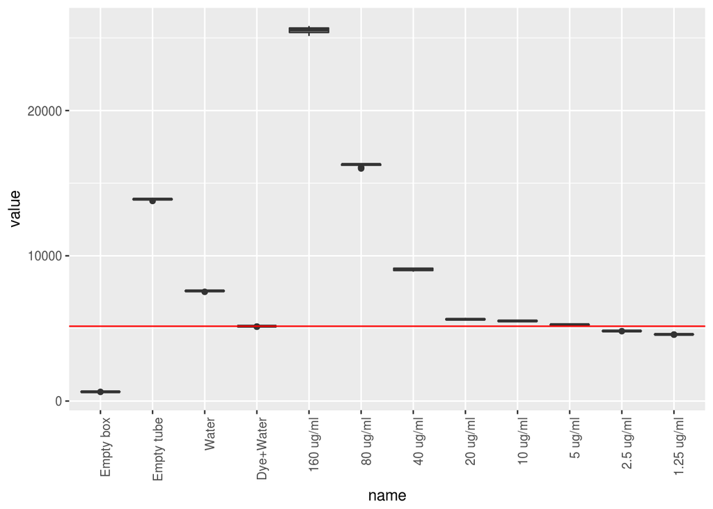

```r
cutoff <- data.frame(yintercept=ctrl_wd_median$m, cutoff=factor(ctrl_wd_median$m))
ds_high %>% filter(gain == "HIGH") %>%
  ggplot() +
  geom_boxplot(mapping = aes(x = name, y = value)) +
  geom_hline(aes(yintercept=yintercept), data=cutoff, colour = "red") +
  scale_x_discrete(limits = c("emptybox", "emptytube", "water", "ctrl_dye_water", "TU1", "TU2", "TU3", "TU4", "TU5", "TU6", "TU7", "TU8"), labels = c("Empty box", "Empty tube", "Water", "Dye+Water", "160 ug/ml", "80 ug/ml", "40 ug/ml", "20 ug/ml", "10 ug/ml", "5 ug/ml", "2.5 ug/ml", "1.25 ug/ml")) +
  theme(axis.text.x = element_text(angle = 90, hjust = 1))
```

The sensor readings for the higher concentrations are quite high when compared to the lower concentrations, so let’s zoom in on the 20 ug/ml to 1.25 ug/ml range:

```r
ctrl_wd_median <- ds_high %>% filter(name == "ctrl_dye_water") %>% summarise(m = median(value))
ctrl_wd_median$m
```

```
## [1] 5153
```

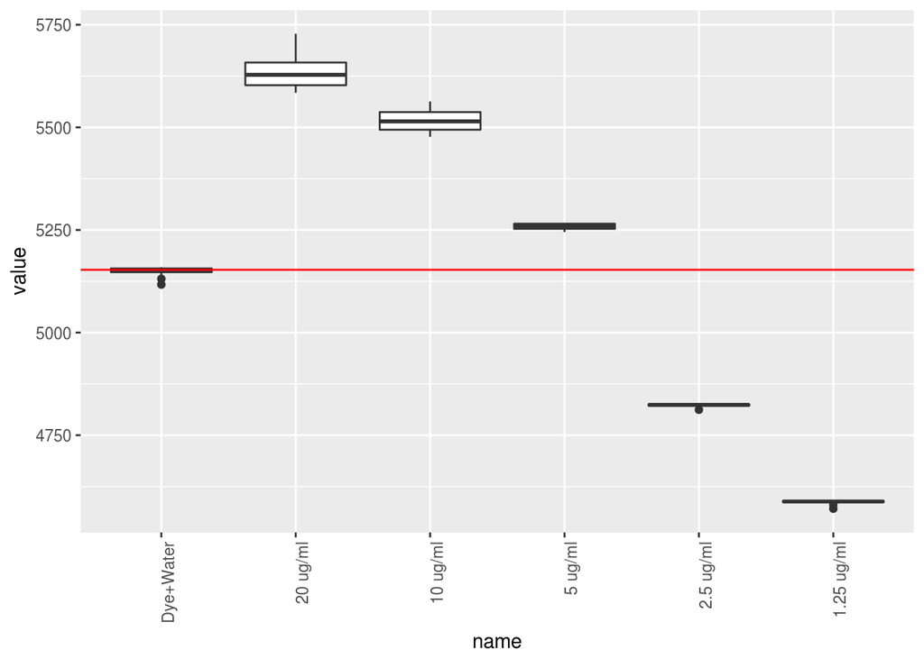

```r
cutoff <- data.frame(yintercept=ctrl_wd_median$m, cutoff=factor(ctrl_wd_median$m))
ds_high %>% filter(gain == "HIGH", (name == "ctrl_dye_water" | name == "TU4" | name == "TU5" | name == "TU6" | name == "TU7" | name == "TU8")) %>%
  ggplot() +
  geom_boxplot(mapping = aes(x = name, y = value)) +
  geom_hline(aes(yintercept=yintercept), data=cutoff, colour = "red") +
  scale_x_discrete(limits = c("ctrl_dye_water","TU4", "TU5", "TU6", "TU7", "TU8"), labels = c("Dye+Water", "20 ug/ml", "10 ug/ml", "5 ug/ml", "2.5 ug/ml", "1.25 ug/ml")) +
  theme(axis.text.x = element_text(angle = 90, hjust = 1))
```

While our samples are not to be considered reliable anymore after sitting around for a day, we decided to make two more sets of measurements, close together: Re-measure all of yesterday’s samples, and then remove the resistor (which turned out to be added by mistake - the NodeMCU only outputs 3.3V instead of the Arduino’s 5V…) and measure again. This should at least maybe get us a little more use out of the samples.

```r
file <- "../data/2018-04-25_GelGreen_50bpladder_replica2.csv"
dataset <- read.csv(file,
              header = TRUE,
              sep = ",",
              comment.char = "#")
```

Let’s check what the highest gain level is for which we have measurements for all samples. MAX first:

```r
# Check whether each measurement has a MAX reading. This is the case if we have the following number of MAX entries:
# number of samples * 20 -> |emptybox, emptytube, ctrl1, ctrl2, TU1, ..., TU8| * 20 -> 12 * 20 = 240
dataset %>% filter(gain == "MAX") %>% summarise(n = n())
```

```
##    n
## 1 20
```

No luck here, most measurements do not have a valid value at gain level MAX. Let’s check HIGH next:

```r
# Check whether each measurement has a HIGH reading. This is the case if we have the following number of HIGH entries:
# number of samples * 20 -> |emptybox, emptytube, ctrl1, ctrl2, TU1, ..., TU8| * 20 -> 12 * 20 = 240
dataset %>% filter(gain == "HIGH") %>% summarise(n = n())
```

```
##     n
## 1 240
```

Ok good, so we can just work with the measurements at gain level high.

```r
ds_high <- dataset %>% filter(gain == "HIGH")
```

Let’s have a first look at the values:

```r
ctrl_wd_median <- ds_high %>% filter(name == "ctrl_dye_water") %>% summarise(m = median(value))
ctrl_wd_median$m
```

```
## [1] 7370.5
```

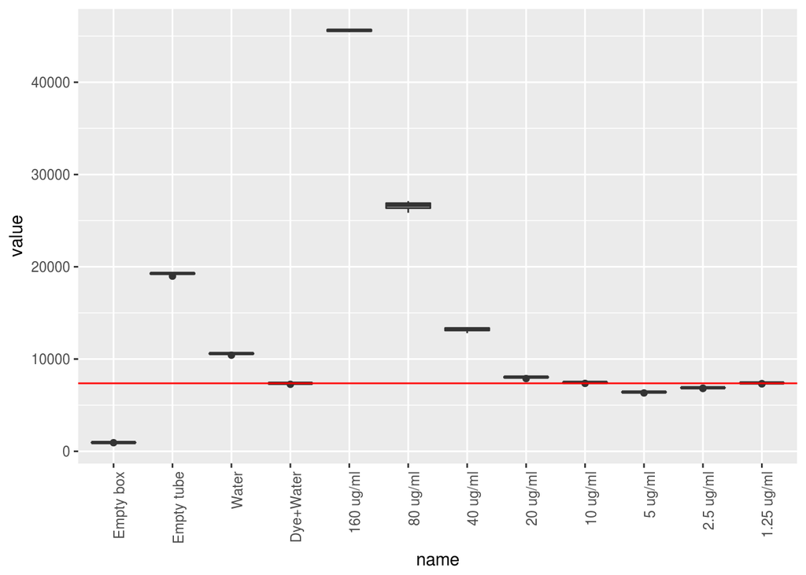

```r
cutoff <- data.frame(yintercept=ctrl_wd_median$m, cutoff=factor(ctrl_wd_median$m))
ds_high %>% filter(gain == "HIGH") %>%
  ggplot() +
  geom_boxplot(mapping = aes(x = name, y = value)) +
  geom_hline(aes(yintercept=yintercept), data=cutoff, colour = "red") +
  scale_x_discrete(limits = c("emptybox", "emptytube", "water", "ctrl_dye_water", "TU1", "TU2", "TU3", "TU4", "TU5", "TU6", "TU7", "TU8"), labels = c("Empty box", "Empty tube", "Water", "Dye+Water", "160 ug/ml", "80 ug/ml", "40 ug/ml", "20 ug/ml", "10 ug/ml", "5 ug/ml", "2.5 ug/ml", "1.25 ug/ml")) +
  theme(axis.text.x = element_text(angle = 90, hjust = 1))
```

The sensor readings for the higher concentrations are quite high when compared to the lower concentrations, so let’s zoom in on the 20 ug/ml to 1.25 ug/ml range:

```r
ctrl_wd_median <- ds_high %>% filter(name == "ctrl_dye_water") %>% summarise(m = median(value))
ctrl_wd_median$m
```

```
## [1] 7370.5
```

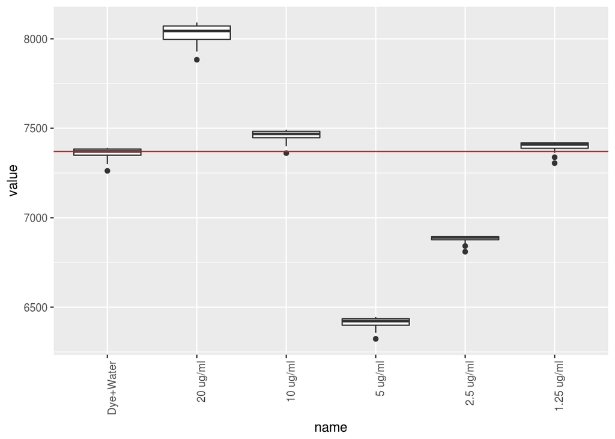

```r
cutoff <- data.frame(yintercept=ctrl_wd_median$m, cutoff=factor(ctrl_wd_median$m))
ds_high %>% filter(gain == "HIGH", (name == "ctrl_dye_water" | name == "TU4" | name == "TU5" | name == "TU6" | name == "TU7" | name == "TU8")) %>%
  ggplot() +
  geom_boxplot(mapping = aes(x = name, y = value)) +
  geom_hline(aes(yintercept=yintercept), data=cutoff, colour = "red") +
  scale_x_discrete(limits = c("ctrl_dye_water","TU4", "TU5", "TU6", "TU7", "TU8"), labels = c("Dye+Water", "20 ug/ml", "10 ug/ml", "5 ug/ml", "2.5 ug/ml", "1.25 ug/ml")) +
  theme(axis.text.x = element_text(angle = 90, hjust = 1))
```

```r
file <- "../data/2018-04-25_GelGreen_50bpladder_replica1.csv"
ds1 <- read.csv(file,
              header = TRUE,
              sep = ",",
              comment.char = "#")
file <- "../data/2018-04-24_GelGreen_50bpladder_1.csv"
ds2 <- read.csv(file,
              header = TRUE,
              sep = ",",
              comment.char = "#")
ds1$experiment <- c("+24h")  # The data in ds2 were recorded 24 hours after the ones in ds1
ds2$experiment <- c("+0h")   #
ds <- rbind(ds1, ds2)
```

```r
#ggplot() +
#  geom_line(mapping = aes(x = seq(1,20), y = value), data = ds, color = "red") +
#  geom_line(mapping = aes(x = seq(1,20), y = value), data = ds, color = "blue") +
#  scale_colour_manual("",
#                      breaks = c("+24h", "0h"),
#                      values = c("red", "blue"))
```

```r
file <- "../data/2018-04-26_GelGreen_QE_replica1.csv"
dataset <- read.csv(file,
              header = TRUE,
              sep = ",",
              comment.char = "#")
```

```r
ds_high <- dataset %>% filter(gain == "HIGH")
```

[output not shown]

[figure not shown]

[output not shown]

[figure not shown]

```r
file <- "../data/2018-04-26_GelGreen_QE_replica1.csv"
ds1 <- read.csv(file,
              header = TRUE,
              sep = ",",
              comment.char = "#")
file <- "../data/2018-04-26_GelGreen_QE_2_replica1.csv"
ds2 <- read.csv(file,
              header = TRUE,
              sep = ",",
              comment.char = "#")
ds1$experiment <- c("QE-1")  # QE-1: First DNA extraction w/ 500ul of QE and 1 swab
ds2$experiment <- c("QE-2")  # QE-2: Second DNA extraction w/ 300ul of QE and 4 swabs
ds <- rbind(ds1, ds2)
ds_high <- ds %>% filter(gain == "HIGH")
ctrl_wd_median <- ds_high %>% filter(name == "ctrl_dye_qe") %>% summarise(m = median(value))
ctrl_wd_median$m
```

```
## [1] 6113
```

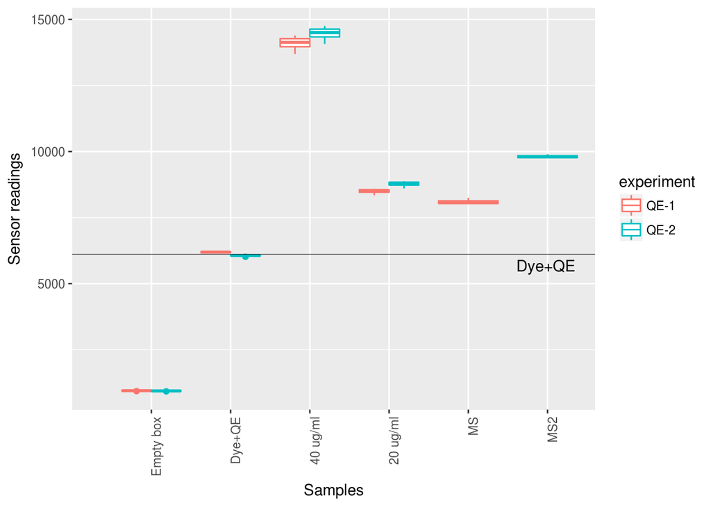

```r
cutoff <- data.frame(yintercept=ctrl_wd_median$m, cutoff=factor(ctrl_wd_median$m))
ds_high %>% filter(gain == "HIGH") %>%
  ggplot() +
  geom_boxplot(mapping = aes(x = name, y = value, colour = experiment)) +
  geom_hline(aes(yintercept=yintercept), data=cutoff, colour = "black", size = 0.2) +
  geom_text(aes(0, yintercept, label = "Dye+QE", vjust = 1.5, hjust = -7.5), data = cutoff) +
  scale_x_discrete(limits = c("emptybox", "ctrl_dye_qe", "TU3", "TU4", "MS", "MS2"), labels = c("Empty box", "Dye+QE", "40 ug/ml", "20 ug/ml", "MS", "MS2")) +
  labs(y = "Sensor readings", x = "Samples") +
  theme(axis.text.x = element_text(angle = 90, hjust = 1))
```

```r
file <- "../data/2018-04-26_GelGreen_QE_2_filters.csv"
ds <- read.csv(file,
              header = TRUE,
              sep = ",",
              comment.char = "#")
ds_high <- ds %>% filter(gain == "HIGH")
ctrl_wd_median <- ds_high %>% filter(name == "ctrl_dye_water") %>% summarise(m = median(value))
ctrl_wd_median$m
```

```
## [1] 1020.5
```

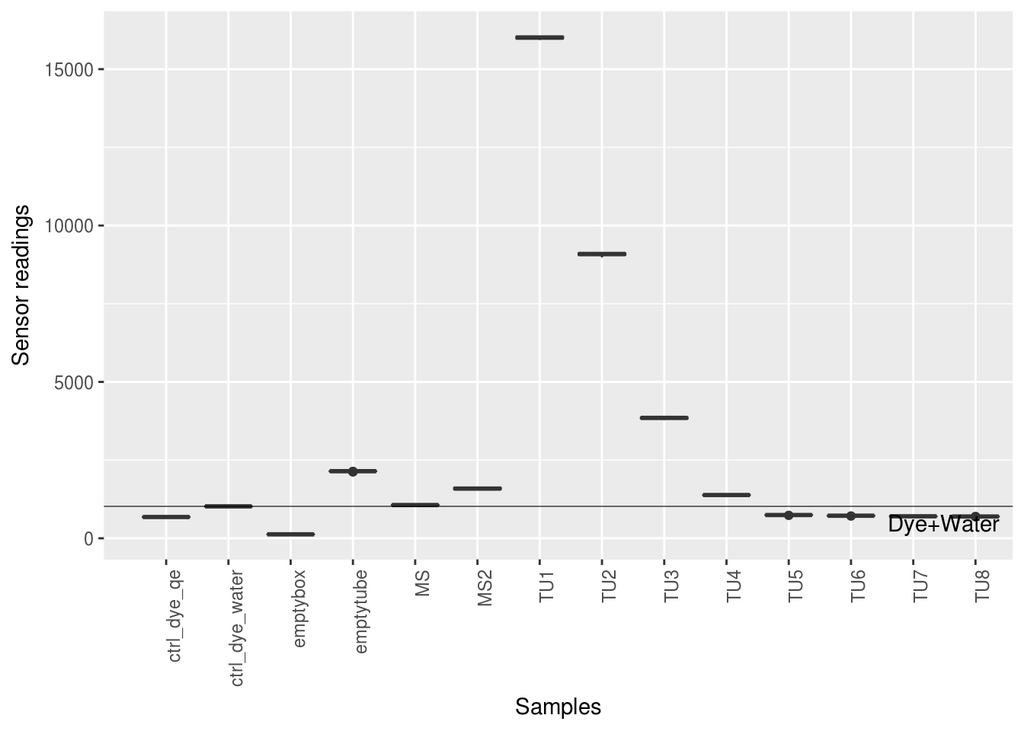

```r
cutoff <- data.frame(yintercept=ctrl_wd_median$m, cutoff=factor(ctrl_wd_median$m))
ds_high %>% filter(gain == "HIGH") %>%
  ggplot() +
  geom_boxplot(mapping = aes(x = name, y = value)) +
  geom_hline(aes(yintercept=yintercept), data=cutoff, colour = "black", size = 0.2) +
  geom_text(aes(0, yintercept, label = "Dye+Water", vjust = 1.5, hjust = -7), data = cutoff) +
#  scale_x_discrete(limits = c("emptybox", "ctrl_dye_qe", "TU3", "TU4", "MS", "MS2"), labels = c("Empty box", "Dye+QE", "40 ug/ml", "20 ug/ml", "MS", "MS2")) +
  labs(y = "Sensor readings", x = "Samples") +
  theme(axis.text.x = element_text(angle = 90, hjust = 1))
```

```r
ds_max <- ds %>% filter(gain == "MAX")
unique(ds_max$name)
```

```
##  [1] emptybox       emptytube      ctrl_dye_water MS2
##  [5] MS             ctrl_dye_qe    TU4            TU5
##  [9] TU6            TU7            TU8
## 14 Levels: ctrl_dye_qe ctrl_dye_water emptybox emptytube MS MS2 ... TU8
```

```r
ds_max <- ds %>% filter(gain == "MAX")
ctrl_wd_median <- ds_max %>% filter(name == "ctrl_dye_water") %>% summarise(m = median(value))
ctrl_wd_median$m
```

```
## [1] 23573
```

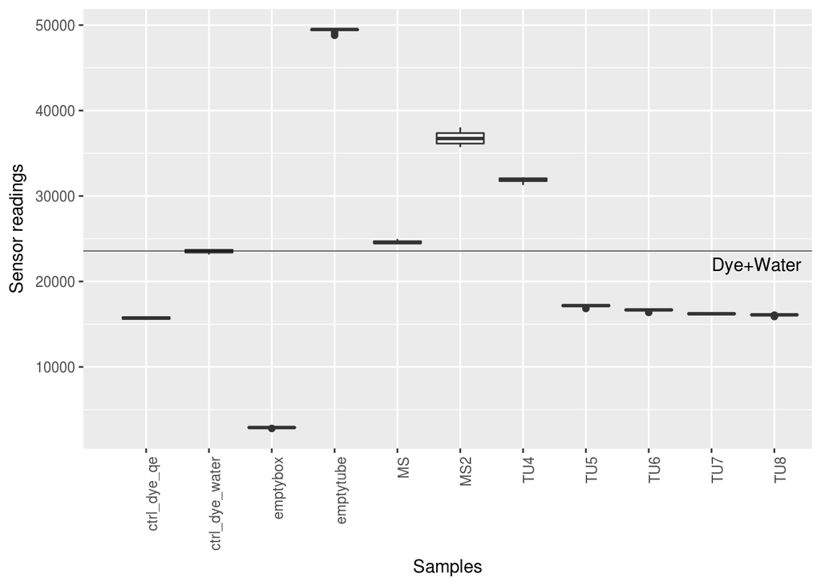

```r
cutoff <- data.frame(yintercept=ctrl_wd_median$m, cutoff=factor(ctrl_wd_median$m))
ds_max %>% filter(name != "TU1", name != "TU2", name != "TU3") %>%
  ggplot() +
  geom_boxplot(mapping = aes(x = name, y = value)) +
  geom_hline(aes(yintercept=yintercept), data=cutoff, colour = "black", size = 0.2) +
  geom_text(aes(0, yintercept, label = "Dye+Water", vjust = 1.5, hjust = -7), data = cutoff) +
#  scale_x_discrete(limits = c("emptybox", "ctrl_dye_qe", "TU3", "TU4", "MS", "MS2"), labels = c("Empty box", "Dye+QE", "40 ug/ml", "20 ug/ml", "MS", "MS2")) +
  labs(y = "Sensor readings", x = "Samples") +
  theme(axis.text.x = element_text(angle = 90, hjust = 1))
```

```r
file <- "../data/2018-04-26_GelGreen_QE_2_filters.csv"
ds1 <- read.csv(file,
              header = TRUE,
              sep = ",",
              comment.char = "#")
file <- "../data/2018-04-27_GelGreen_QE_2_filters_plus24h.csv"
ds2 <- read.csv(file,
              header = TRUE,
              sep = ",",
              comment.char = "#")
ds1$experiment <- c("QE+0")  # QE+0: 2nd DNA extraction w/ 300ul of QE and 4 swabs, dichroic+glass filters
ds2$experiment <- c("QE+24")  # QE+24: Same as QE-1, but measured again 24 hours later
ds <- rbind(ds1, ds2)
ds_high <- ds %>% filter(gain == "HIGH")
ctrl_wd_median <- ds_high %>% filter(name == "ctrl_dye_qe") %>% summarise(m = median(value))
ctrl_wd_median$m
```

```
## [1] 667.5
```

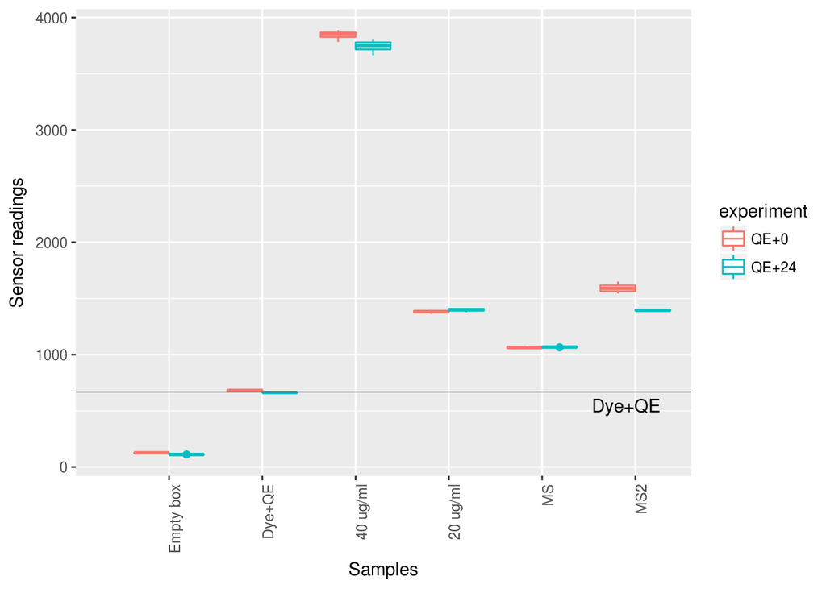

```r
cutoff <- data.frame(yintercept=ctrl_wd_median$m, cutoff=factor(ctrl_wd_median$m))
ds_high %>% filter(gain == "HIGH") %>%
  ggplot() +
  geom_boxplot(mapping = aes(x = name, y = value, colour = experiment)) +
  geom_hline(aes(yintercept=yintercept), data=cutoff, colour = "black", size = 0.2) +
  geom_text(aes(0, yintercept, label = "Dye+QE", vjust = 1.5, hjust = -7.5), data = cutoff) +
  scale_x_discrete(limits = c("emptybox", "ctrl_dye_qe", "TU3", "TU4", "MS", "MS2"), labels = c("Empty box", "Dye+QE", "40 ug/ml", "20 ug/ml", "MS", "MS2")) +
  labs(y = "Sensor readings", x = "Samples") +
  theme(axis.text.x = element_text(angle = 90, hjust = 1))
```

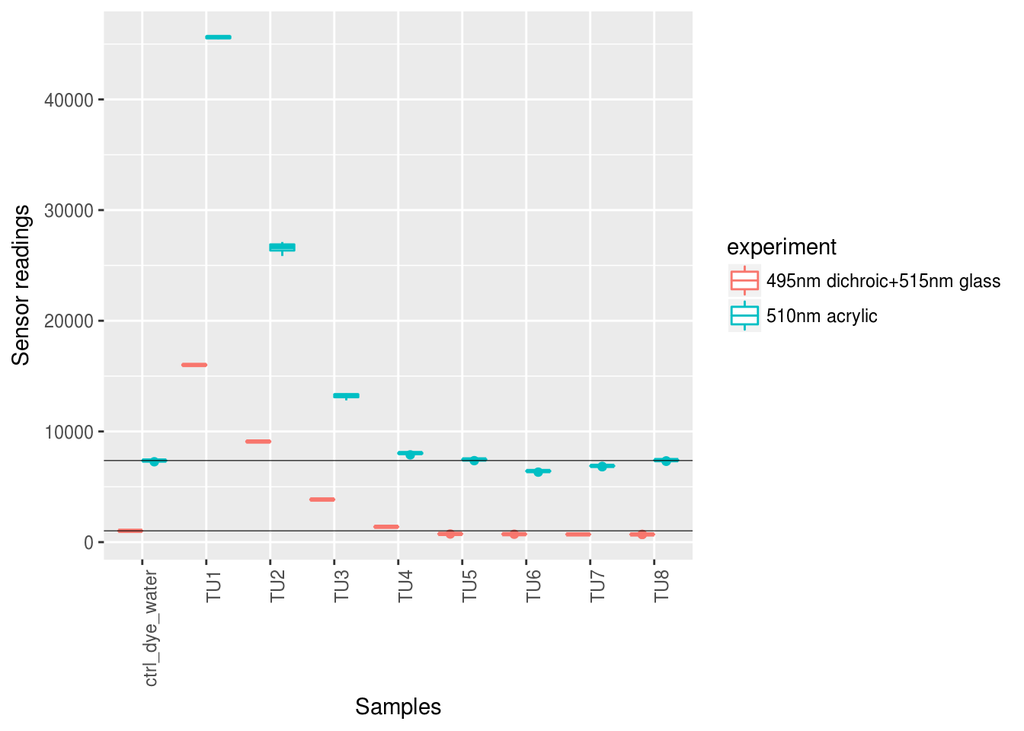

```r
file <- "../data/2018-04-25_GelGreen_50bpladder_replica2.csv"
ds1 <- read.csv(file,
              header = TRUE,
              sep = ",",
              comment.char = "#")
file <- "../data/2018-04-26_GelGreen_QE_2_replica1.csv"
ds2 <- read.csv(file,
              header = TRUE,
              sep = ",",
              comment.char = "#")
file <- "../data/2018-04-26_GelGreen_QE_2_filters.csv"
ds3 <- read.csv(file,
              header = TRUE,
              sep = ",",
              comment.char = "#")
ds1$experiment <- c("510nm acrylic")  # ladder only, filter: 510nm acrylic
ds2$experiment <- c("QE, 510a")  # DNA extraction, filter: 510nm acrylic
ds3$experiment <- c("495nm dichroic+515nm glass")  # DNA extraction, filters: dichroic + glass long-pass
#ds <- rbind(ds1, ds2, ds3)
ds <- rbind(ds1, ds3)

ds_high <- ds %>% filter(gain == "HIGH", name != "ctrl_dye_qe", name != "MS", name != "MS2", name != "water", name != "emptybox", name != "emptytube")
ds1_ctrl_wd_median <- ds_high %>% filter(name == "ctrl_dye_water", experiment == "510nm acrylic") %>% summarise(m = median(value))
ds2_ctrl_wd_median <- ds_high %>% filter(name == "ctrl_dye_water", experiment == "495nm dichroic+515nm glass") %>% summarise(m = median(value))
cutoff1 <- data.frame(yintercept=ds1_ctrl_wd_median$m, cutoff=factor(ds1_ctrl_wd_median$m))
cutoff2 <- data.frame(yintercept=ds2_ctrl_wd_median$m, cutoff=factor(ds2_ctrl_wd_median$m))
ds_high %>%
  ggplot() +
  geom_boxplot(mapping = aes(x = name, y = value, colour = experiment)) +
  geom_hline(aes(yintercept=yintercept), data=cutoff1, colour = "black", size = 0.2) +
#  geom_text(aes(0, yintercept, label = "Dye+Water 510nm", vjust = 1.5, hjust = -2), data = cutoff1) +
  geom_hline(aes(yintercept=yintercept), data=cutoff2, colour = "black", size = 0.2) +
#  geom_text(aes(0, yintercept, label = "Dye+Water Dichroic+glass", vjust = 1.5, hjust = -2), data = cutoff2) +
  labs(y = "Sensor readings", x = "Samples") +
  theme(axis.text.x = element_text(angle = 90, hjust = 1))
```

I’m looking at the difference between the filter sets again: 510nm acrylic long-pass versus a combination of short-pass dichroic 495nm and long-pass glass 515nm. Generally speaking, the dichroic/glass combination results in much less light reaching the sensor (which is to be expected). However, this difference in light levels is not constant; there appears to be some correlation to the DNA concentration. The following is a graph of the differences between corresponding measurements for each set of filters:

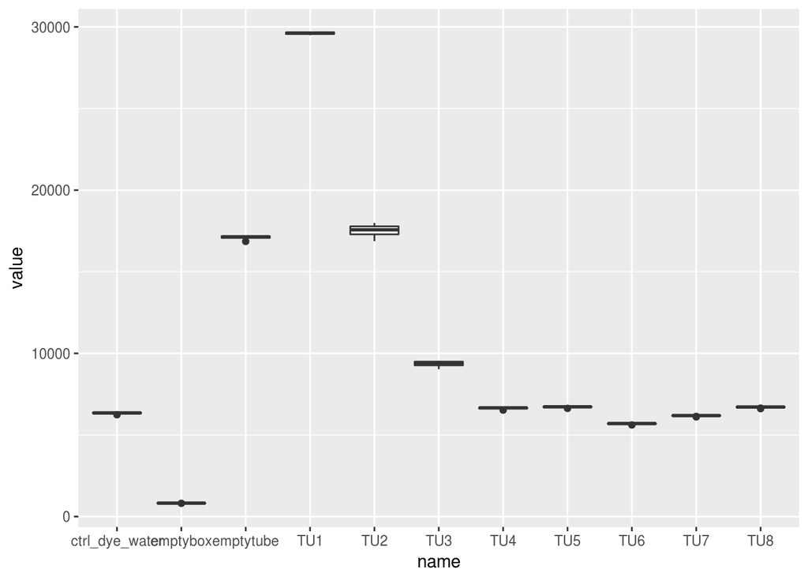

```r
ds <- read.csv("/home/lisa/projects/biolab/hardware/fluorometer/aolw2018-capetown/data/2018-04-28_510nm_dichroicglass_diff.csv", header = TRUE, sep = ",", comment.char = "#")
ds %>% filter(gain == "HIGH") %>% ggplot() + geom_boxplot(mapping = aes(x = name, y = value))
```

Looking at this picture, it appears that the 510nm acrylic long-pass filter lets through a lot more of the emission light, whereas the dichroic/glass combination filters out a lot of that emissions light? Because if the dichroic/glass combination only (or mostly) filtered out the excitation light as desired, the difference between the two samples would be more or less constant. I think it’s interesting here to look at ctrl_dye_water, emptybox and emptytube. The difference for emptybox is insubstantial. The difference for emptytube, however, is not. It’s actually quite big. Since in this sample, all light reaching the sensor must be excitation light, we can conclude that the dichroic/glass combination succeeds at filtering out quite a bit of the excitation light. There are two possibilities here: 1) The dichroic filter takes away too much light that would otherwise lead to increased excitement of the fluorescent dye and thus more fluorescence. 2) The 515nm long-pass filter takes away too much of the fluorescent light. To resolve this, I should take measurements with more combinations of filters: 515nm glass only, and 510nm acrylic plus dichroic.

The following at least generates a data frame with the median for all values of a measurement series and gain

```r
ds1 %>% group_by(name, gain) %>% summarize(n = n(), med = median(value))
```

```
## # A tibble: 37 x 4
## # Groups:   name [?]
##              name   gain     n     med
##            <fctr> <fctr> <int>   <dbl>
##  1 ctrl_dye_water   HIGH    20  7370.5
##  2 ctrl_dye_water    LOW    20    17.0
##  3 ctrl_dye_water    MED    20   426.5
##  4       emptybox   HIGH    20   950.0
##  5       emptybox    LOW    20     2.0
##  6       emptybox    MAX    20 21937.5
##  7       emptybox    MED    20    56.0
##  8      emptytube   HIGH    20 19279.5
##  9      emptytube    LOW    20    46.0
## 10      emptytube    MED    20  1121.0
## # ... with 27 more rows
```